# Automotive Data Analysis

#### Nishant Madu

```python
import numpy as np
import pandas as pd
import matplotlib.pyplot as plt
import seaborn as sns
%matplotlib inline
auto=pd.read_csv('Automobile_data.txt')
auto
```

|  | symboling | normalized-losses | make | fuel-type | aspiration | num-of-doors | body-style | drive-wheels | engine-location | wheel-base | ... | engine-size | fuel-system | bore | stroke | compression-ratio | horsepower | peak-rpm | city-mpg | highway-mpg | price |
| --- | --- | --- | --- | --- | --- | --- | --- | --- | --- | --- | --- | --- | --- | --- | --- | --- | --- | --- | --- | --- | --- |
| 0 | 3 | ? | alfa-romero | gas | std | two | convertible | rwd | front | 88.6 | ... | 130 | mpfi | 3.47 | 2.68 | 9.00 | 111 | 5000 | 21 | 27 | 13495 |
| 1 | 3 | ? | alfa-romero | gas | std | two | convertible | rwd | front | 88.6 | ... | 130 | mpfi | 3.47 | 2.68 | 9.00 | 111 | 5000 | 21 | 27 | 16500 |
| 2 | 1 | ? | alfa-romero | gas | std | two | hatchback | rwd | front | 94.5 | ... | 152 | mpfi | 2.68 | 3.47 | 9.00 | 154 | 5000 | 19 | 26 | 16500 |
| 3 | 2 | 164 | audi | gas | std | four | sedan | fwd | front | 99.8 | ... | 109 | mpfi | 3.19 | 3.40 | 10.00 | 102 | 5500 | 24 | 30 | 13950 |
| 4 | 2 | 164 | audi | gas | std | four | sedan | 4wd | front | 99.4 | ... | 136 | mpfi | 3.19 | 3.40 | 8.00 | 115 | 5500 | 18 | 22 | 17450 |
| 5 | 2 | ? | audi | gas | std | two | sedan | fwd | front | 99.8 | ... | 136 | mpfi | 3.19 | 3.40 | 8.50 | 110 | 5500 | 19 | 25 | 15250 |
| 6 | 1 | 158 | audi | gas | std | four | sedan | fwd | front | 105.8 | ... | 136 | mpfi | 3.19 | 3.40 | 8.50 | 110 | 5500 | 19 | 25 | 17710 |
| 7 | 1 | ? | audi | gas | std | four | wagon | fwd | front | 105.8 | ... | 136 | mpfi | 3.19 | 3.40 | 8.50 | 110 | 5500 | 19 | 25 | 18920 |
| 8 | 1 | 158 | audi | gas | turbo | four | sedan | fwd | front | 105.8 | ... | 131 | mpfi | 3.13 | 3.40 | 8.30 | 140 | 5500 | 17 | 20 | 23875 |
| 9 | 0 | ? | audi | gas | turbo | two | hatchback | 4wd | front | 99.5 | ... | 131 | mpfi | 3.13 | 3.40 | 7.00 | 160 | 5500 | 16 | 22 | ? |
| 10 | 2 | 192 | bmw | gas | std | two | sedan | rwd | front | 101.2 | ... | 108 | mpfi | 3.50 | 2.80 | 8.80 | 101 | 5800 | 23 | 29 | 16430 |
| 11 | 0 | 192 | bmw | gas | std | four | sedan | rwd | front | 101.2 | ... | 108 | mpfi | 3.50 | 2.80 | 8.80 | 101 | 5800 | 23 | 29 | 16925 |
| 12 | 0 | 188 | bmw | gas | std | two | sedan | rwd | front | 101.2 | ... | 164 | mpfi | 3.31 | 3.19 | 9.00 | 121 | 4250 | 21 | 28 | 20970 |
| 13 | 0 | 188 | bmw | gas | std | four | sedan | rwd | front | 101.2 | ... | 164 | mpfi | 3.31 | 3.19 | 9.00 | 121 | 4250 | 21 | 28 | 21105 |
| 14 | 1 | ? | bmw | gas | std | four | sedan | rwd | front | 103.5 | ... | 164 | mpfi | 3.31 | 3.19 | 9.00 | 121 | 4250 | 20 | 25 | 24565 |
| 15 | 0 | ? | bmw | gas | std | four | sedan | rwd | front | 103.5 | ... | 209 | mpfi | 3.62 | 3.39 | 8.00 | 182 | 5400 | 16 | 22 | 30760 |
| 16 | 0 | ? | bmw | gas | std | two | sedan | rwd | front | 103.5 | ... | 209 | mpfi | 3.62 | 3.39 | 8.00 | 182 | 5400 | 16 | 22 | 41315 |
| 17 | 0 | ? | bmw | gas | std | four | sedan | rwd | front | 110.0 | ... | 209 | mpfi | 3.62 | 3.39 | 8.00 | 182 | 5400 | 15 | 20 | 36880 |
| 18 | 2 | 121 | chevrolet | gas | std | two | hatchback | fwd | front | 88.4 | ... | 61 | 2bbl | 2.91 | 3.03 | 9.50 | 48 | 5100 | 47 | 53 | 5151 |
| 19 | 1 | 98 | chevrolet | gas | std | two | hatchback | fwd | front | 94.5 | ... | 90 | 2bbl | 3.03 | 3.11 | 9.60 | 70 | 5400 | 38 | 43 | 6295 |
| 20 | 0 | 81 | chevrolet | gas | std | four | sedan | fwd | front | 94.5 | ... | 90 | 2bbl | 3.03 | 3.11 | 9.60 | 70 | 5400 | 38 | 43 | 6575 |
| 21 | 1 | 118 | dodge | gas | std | two | hatchback | fwd | front | 93.7 | ... | 90 | 2bbl | 2.97 | 3.23 | 9.41 | 68 | 5500 | 37 | 41 | 5572 |
| 22 | 1 | 118 | dodge | gas | std | two | hatchback | fwd | front | 93.7 | ... | 90 | 2bbl | 2.97 | 3.23 | 9.40 | 68 | 5500 | 31 | 38 | 6377 |
| 23 | 1 | 118 | dodge | gas | turbo | two | hatchback | fwd | front | 93.7 | ... | 98 | mpfi | 3.03 | 3.39 | 7.60 | 102 | 5500 | 24 | 30 | 7957 |
| 24 | 1 | 148 | dodge | gas | std | four | hatchback | fwd | front | 93.7 | ... | 90 | 2bbl | 2.97 | 3.23 | 9.40 | 68 | 5500 | 31 | 38 | 6229 |
| 25 | 1 | 148 | dodge | gas | std | four | sedan | fwd | front | 93.7 | ... | 90 | 2bbl | 2.97 | 3.23 | 9.40 | 68 | 5500 | 31 | 38 | 6692 |
| 26 | 1 | 148 | dodge | gas | std | four | sedan | fwd | front | 93.7 | ... | 90 | 2bbl | 2.97 | 3.23 | 9.40 | 68 | 5500 | 31 | 38 | 7609 |
| 27 | 1 | 148 | dodge | gas | turbo | ? | sedan | fwd | front | 93.7 | ... | 98 | mpfi | 3.03 | 3.39 | 7.60 | 102 | 5500 | 24 | 30 | 8558 |
| 28 | -1 | 110 | dodge | gas | std | four | wagon | fwd | front | 103.3 | ... | 122 | 2bbl | 3.34 | 3.46 | 8.50 | 88 | 5000 | 24 | 30 | 8921 |
| 29 | 3 | 145 | dodge | gas | turbo | two | hatchback | fwd | front | 95.9 | ... | 156 | mfi | 3.60 | 3.90 | 7.00 | 145 | 5000 | 19 | 24 | 12964 |
| ... | ... | ... | ... | ... | ... | ... | ... | ... | ... | ... | ... | ... | ... | ... | ... | ... | ... | ... | ... | ... | ... |
| 175 | -1 | 65 | toyota | gas | std | four | hatchback | fwd | front | 102.4 | ... | 122 | mpfi | 3.31 | 3.54 | 8.70 | 92 | 4200 | 27 | 32 | 9988 |
| 176 | -1 | 65 | toyota | gas | std | four | sedan | fwd | front | 102.4 | ... | 122 | mpfi | 3.31 | 3.54 | 8.70 | 92 | 4200 | 27 | 32 | 10898 |
| 177 | -1 | 65 | toyota | gas | std | four | hatchback | fwd | front | 102.4 | ... | 122 | mpfi | 3.31 | 3.54 | 8.70 | 92 | 4200 | 27 | 32 | 11248 |
| 178 | 3 | 197 | toyota | gas | std | two | hatchback | rwd | front | 102.9 | ... | 171 | mpfi | 3.27 | 3.35 | 9.30 | 161 | 5200 | 20 | 24 | 16558 |
| 179 | 3 | 197 | toyota | gas | std | two | hatchback | rwd | front | 102.9 | ... | 171 | mpfi | 3.27 | 3.35 | 9.30 | 161 | 5200 | 19 | 24 | 15998 |
| 180 | -1 | 90 | toyota | gas | std | four | sedan | rwd | front | 104.5 | ... | 171 | mpfi | 3.27 | 3.35 | 9.20 | 156 | 5200 | 20 | 24 | 15690 |
| 181 | -1 | ? | toyota | gas | std | four | wagon | rwd | front | 104.5 | ... | 161 | mpfi | 3.27 | 3.35 | 9.20 | 156 | 5200 | 19 | 24 | 15750 |
| 182 | 2 | 122 | volkswagen | diesel | std | two | sedan | fwd | front | 97.3 | ... | 97 | idi | 3.01 | 3.40 | 23.00 | 52 | 4800 | 37 | 46 | 7775 |
| 183 | 2 | 122 | volkswagen | gas | std | two | sedan | fwd | front | 97.3 | ... | 109 | mpfi | 3.19 | 3.40 | 9.00 | 85 | 5250 | 27 | 34 | 7975 |
| 184 | 2 | 94 | volkswagen | diesel | std | four | sedan | fwd | front | 97.3 | ... | 97 | idi | 3.01 | 3.40 | 23.00 | 52 | 4800 | 37 | 46 | 7995 |
| 185 | 2 | 94 | volkswagen | gas | std | four | sedan | fwd | front | 97.3 | ... | 109 | mpfi | 3.19 | 3.40 | 9.00 | 85 | 5250 | 27 | 34 | 8195 |
| 186 | 2 | 94 | volkswagen | gas | std | four | sedan | fwd | front | 97.3 | ... | 109 | mpfi | 3.19 | 3.40 | 9.00 | 85 | 5250 | 27 | 34 | 8495 |
| 187 | 2 | 94 | volkswagen | diesel | turbo | four | sedan | fwd | front | 97.3 | ... | 97 | idi | 3.01 | 3.40 | 23.00 | 68 | 4500 | 37 | 42 | 9495 |
| 188 | 2 | 94 | volkswagen | gas | std | four | sedan | fwd | front | 97.3 | ... | 109 | mpfi | 3.19 | 3.40 | 10.00 | 100 | 5500 | 26 | 32 | 9995 |
| 189 | 3 | ? | volkswagen | gas | std | two | convertible | fwd | front | 94.5 | ... | 109 | mpfi | 3.19 | 3.40 | 8.50 | 90 | 5500 | 24 | 29 | 11595 |
| 190 | 3 | 256 | volkswagen | gas | std | two | hatchback | fwd | front | 94.5 | ... | 109 | mpfi | 3.19 | 3.40 | 8.50 | 90 | 5500 | 24 | 29 | 9980 |
| 191 | 0 | ? | volkswagen | gas | std | four | sedan | fwd | front | 100.4 | ... | 136 | mpfi | 3.19 | 3.40 | 8.50 | 110 | 5500 | 19 | 24 | 13295 |
| 192 | 0 | ? | volkswagen | diesel | turbo | four | sedan | fwd | front | 100.4 | ... | 97 | idi | 3.01 | 3.40 | 23.00 | 68 | 4500 | 33 | 38 | 13845 |
| 193 | 0 | ? | volkswagen | gas | std | four | wagon | fwd | front | 100.4 | ... | 109 | mpfi | 3.19 | 3.40 | 9.00 | 88 | 5500 | 25 | 31 | 12290 |
| 194 | -2 | 103 | volvo | gas | std | four | sedan | rwd | front | 104.3 | ... | 141 | mpfi | 3.78 | 3.15 | 9.50 | 114 | 5400 | 23 | 28 | 12940 |
| 195 | -1 | 74 | volvo | gas | std | four | wagon | rwd | front | 104.3 | ... | 141 | mpfi | 3.78 | 3.15 | 9.50 | 114 | 5400 | 23 | 28 | 13415 |
| 196 | -2 | 103 | volvo | gas | std | four | sedan | rwd | front | 104.3 | ... | 141 | mpfi | 3.78 | 3.15 | 9.50 | 114 | 5400 | 24 | 28 | 15985 |
| 197 | -1 | 74 | volvo | gas | std | four | wagon | rwd | front | 104.3 | ... | 141 | mpfi | 3.78 | 3.15 | 9.50 | 114 | 5400 | 24 | 28 | 16515 |
| 198 | -2 | 103 | volvo | gas | turbo | four | sedan | rwd | front | 104.3 | ... | 130 | mpfi | 3.62 | 3.15 | 7.50 | 162 | 5100 | 17 | 22 | 18420 |
| 199 | -1 | 74 | volvo | gas | turbo | four | wagon | rwd | front | 104.3 | ... | 130 | mpfi | 3.62 | 3.15 | 7.50 | 162 | 5100 | 17 | 22 | 18950 |
| 200 | -1 | 95 | volvo | gas | std | four | sedan | rwd | front | 109.1 | ... | 141 | mpfi | 3.78 | 3.15 | 9.50 | 114 | 5400 | 23 | 28 | 16845 |
| 201 | -1 | 95 | volvo | gas | turbo | four | sedan | rwd | front | 109.1 | ... | 141 | mpfi | 3.78 | 3.15 | 8.70 | 160 | 5300 | 19 | 25 | 19045 |
| 202 | -1 | 95 | volvo | gas | std | four | sedan | rwd | front | 109.1 | ... | 173 | mpfi | 3.58 | 2.87 | 8.80 | 134 | 5500 | 18 | 23 | 21485 |
| 203 | -1 | 95 | volvo | diesel | turbo | four | sedan | rwd | front | 109.1 | ... | 145 | idi | 3.01 | 3.40 | 23.00 | 106 | 4800 | 26 | 27 | 22470 |
| 204 | -1 | 95 | volvo | gas | turbo | four | sedan | rwd | front | 109.1 | ... | 141 | mpfi | 3.78 | 3.15 | 9.50 | 114 | 5400 | 19 | 25 | 22625 |

205 rows × 26 columns

## Cleaning the Garbage Values-

#### -Replace all the garbage values to NaN by using the 'replace' method.

#### -Once the method is applied all the garbage values will be replaced by NaN

```python
automobile=auto.replace('?', np.nan)
automobile
```

|  | symboling | normalized-losses | make | fuel-type | aspiration | num-of-doors | body-style | drive-wheels | engine-location | wheel-base | ... | engine-size | fuel-system | bore | stroke | compression-ratio | horsepower | peak-rpm | city-mpg | highway-mpg | price |
| --- | --- | --- | --- | --- | --- | --- | --- | --- | --- | --- | --- | --- | --- | --- | --- | --- | --- | --- | --- | --- | --- |
| 0 | 3 | NaN | alfa-romero | gas | std | two | convertible | rwd | front | 88.6 | ... | 130 | mpfi | 3.47 | 2.68 | 9.00 | 111 | 5000 | 21 | 27 | 13495 |
| 1 | 3 | NaN | alfa-romero | gas | std | two | convertible | rwd | front | 88.6 | ... | 130 | mpfi | 3.47 | 2.68 | 9.00 | 111 | 5000 | 21 | 27 | 16500 |
| 2 | 1 | NaN | alfa-romero | gas | std | two | hatchback | rwd | front | 94.5 | ... | 152 | mpfi | 2.68 | 3.47 | 9.00 | 154 | 5000 | 19 | 26 | 16500 |
| 3 | 2 | 164 | audi | gas | std | four | sedan | fwd | front | 99.8 | ... | 109 | mpfi | 3.19 | 3.40 | 10.00 | 102 | 5500 | 24 | 30 | 13950 |
| 4 | 2 | 164 | audi | gas | std | four | sedan | 4wd | front | 99.4 | ... | 136 | mpfi | 3.19 | 3.40 | 8.00 | 115 | 5500 | 18 | 22 | 17450 |
| 5 | 2 | NaN | audi | gas | std | two | sedan | fwd | front | 99.8 | ... | 136 | mpfi | 3.19 | 3.40 | 8.50 | 110 | 5500 | 19 | 25 | 15250 |
| 6 | 1 | 158 | audi | gas | std | four | sedan | fwd | front | 105.8 | ... | 136 | mpfi | 3.19 | 3.40 | 8.50 | 110 | 5500 | 19 | 25 | 17710 |
| 7 | 1 | NaN | audi | gas | std | four | wagon | fwd | front | 105.8 | ... | 136 | mpfi | 3.19 | 3.40 | 8.50 | 110 | 5500 | 19 | 25 | 18920 |
| 8 | 1 | 158 | audi | gas | turbo | four | sedan | fwd | front | 105.8 | ... | 131 | mpfi | 3.13 | 3.40 | 8.30 | 140 | 5500 | 17 | 20 | 23875 |
| 9 | 0 | NaN | audi | gas | turbo | two | hatchback | 4wd | front | 99.5 | ... | 131 | mpfi | 3.13 | 3.40 | 7.00 | 160 | 5500 | 16 | 22 | NaN |
| 10 | 2 | 192 | bmw | gas | std | two | sedan | rwd | front | 101.2 | ... | 108 | mpfi | 3.50 | 2.80 | 8.80 | 101 | 5800 | 23 | 29 | 16430 |
| 11 | 0 | 192 | bmw | gas | std | four | sedan | rwd | front | 101.2 | ... | 108 | mpfi | 3.50 | 2.80 | 8.80 | 101 | 5800 | 23 | 29 | 16925 |
| 12 | 0 | 188 | bmw | gas | std | two | sedan | rwd | front | 101.2 | ... | 164 | mpfi | 3.31 | 3.19 | 9.00 | 121 | 4250 | 21 | 28 | 20970 |
| 13 | 0 | 188 | bmw | gas | std | four | sedan | rwd | front | 101.2 | ... | 164 | mpfi | 3.31 | 3.19 | 9.00 | 121 | 4250 | 21 | 28 | 21105 |
| 14 | 1 | NaN | bmw | gas | std | four | sedan | rwd | front | 103.5 | ... | 164 | mpfi | 3.31 | 3.19 | 9.00 | 121 | 4250 | 20 | 25 | 24565 |
| 15 | 0 | NaN | bmw | gas | std | four | sedan | rwd | front | 103.5 | ... | 209 | mpfi | 3.62 | 3.39 | 8.00 | 182 | 5400 | 16 | 22 | 30760 |
| 16 | 0 | NaN | bmw | gas | std | two | sedan | rwd | front | 103.5 | ... | 209 | mpfi | 3.62 | 3.39 | 8.00 | 182 | 5400 | 16 | 22 | 41315 |
| 17 | 0 | NaN | bmw | gas | std | four | sedan | rwd | front | 110.0 | ... | 209 | mpfi | 3.62 | 3.39 | 8.00 | 182 | 5400 | 15 | 20 | 36880 |
| 18 | 2 | 121 | chevrolet | gas | std | two | hatchback | fwd | front | 88.4 | ... | 61 | 2bbl | 2.91 | 3.03 | 9.50 | 48 | 5100 | 47 | 53 | 5151 |
| 19 | 1 | 98 | chevrolet | gas | std | two | hatchback | fwd | front | 94.5 | ... | 90 | 2bbl | 3.03 | 3.11 | 9.60 | 70 | 5400 | 38 | 43 | 6295 |
| 20 | 0 | 81 | chevrolet | gas | std | four | sedan | fwd | front | 94.5 | ... | 90 | 2bbl | 3.03 | 3.11 | 9.60 | 70 | 5400 | 38 | 43 | 6575 |
| 21 | 1 | 118 | dodge | gas | std | two | hatchback | fwd | front | 93.7 | ... | 90 | 2bbl | 2.97 | 3.23 | 9.41 | 68 | 5500 | 37 | 41 | 5572 |
| 22 | 1 | 118 | dodge | gas | std | two | hatchback | fwd | front | 93.7 | ... | 90 | 2bbl | 2.97 | 3.23 | 9.40 | 68 | 5500 | 31 | 38 | 6377 |
| 23 | 1 | 118 | dodge | gas | turbo | two | hatchback | fwd | front | 93.7 | ... | 98 | mpfi | 3.03 | 3.39 | 7.60 | 102 | 5500 | 24 | 30 | 7957 |
| 24 | 1 | 148 | dodge | gas | std | four | hatchback | fwd | front | 93.7 | ... | 90 | 2bbl | 2.97 | 3.23 | 9.40 | 68 | 5500 | 31 | 38 | 6229 |
| 25 | 1 | 148 | dodge | gas | std | four | sedan | fwd | front | 93.7 | ... | 90 | 2bbl | 2.97 | 3.23 | 9.40 | 68 | 5500 | 31 | 38 | 6692 |
| 26 | 1 | 148 | dodge | gas | std | four | sedan | fwd | front | 93.7 | ... | 90 | 2bbl | 2.97 | 3.23 | 9.40 | 68 | 5500 | 31 | 38 | 7609 |
| 27 | 1 | 148 | dodge | gas | turbo | NaN | sedan | fwd | front | 93.7 | ... | 98 | mpfi | 3.03 | 3.39 | 7.60 | 102 | 5500 | 24 | 30 | 8558 |
| 28 | -1 | 110 | dodge | gas | std | four | wagon | fwd | front | 103.3 | ... | 122 | 2bbl | 3.34 | 3.46 | 8.50 | 88 | 5000 | 24 | 30 | 8921 |
| 29 | 3 | 145 | dodge | gas | turbo | two | hatchback | fwd | front | 95.9 | ... | 156 | mfi | 3.60 | 3.90 | 7.00 | 145 | 5000 | 19 | 24 | 12964 |
| ... | ... | ... | ... | ... | ... | ... | ... | ... | ... | ... | ... | ... | ... | ... | ... | ... | ... | ... | ... | ... | ... |
| 175 | -1 | 65 | toyota | gas | std | four | hatchback | fwd | front | 102.4 | ... | 122 | mpfi | 3.31 | 3.54 | 8.70 | 92 | 4200 | 27 | 32 | 9988 |
| 176 | -1 | 65 | toyota | gas | std | four | sedan | fwd | front | 102.4 | ... | 122 | mpfi | 3.31 | 3.54 | 8.70 | 92 | 4200 | 27 | 32 | 10898 |
| 177 | -1 | 65 | toyota | gas | std | four | hatchback | fwd | front | 102.4 | ... | 122 | mpfi | 3.31 | 3.54 | 8.70 | 92 | 4200 | 27 | 32 | 11248 |
| 178 | 3 | 197 | toyota | gas | std | two | hatchback | rwd | front | 102.9 | ... | 171 | mpfi | 3.27 | 3.35 | 9.30 | 161 | 5200 | 20 | 24 | 16558 |
| 179 | 3 | 197 | toyota | gas | std | two | hatchback | rwd | front | 102.9 | ... | 171 | mpfi | 3.27 | 3.35 | 9.30 | 161 | 5200 | 19 | 24 | 15998 |
| 180 | -1 | 90 | toyota | gas | std | four | sedan | rwd | front | 104.5 | ... | 171 | mpfi | 3.27 | 3.35 | 9.20 | 156 | 5200 | 20 | 24 | 15690 |
| 181 | -1 | NaN | toyota | gas | std | four | wagon | rwd | front | 104.5 | ... | 161 | mpfi | 3.27 | 3.35 | 9.20 | 156 | 5200 | 19 | 24 | 15750 |
| 182 | 2 | 122 | volkswagen | diesel | std | two | sedan | fwd | front | 97.3 | ... | 97 | idi | 3.01 | 3.40 | 23.00 | 52 | 4800 | 37 | 46 | 7775 |
| 183 | 2 | 122 | volkswagen | gas | std | two | sedan | fwd | front | 97.3 | ... | 109 | mpfi | 3.19 | 3.40 | 9.00 | 85 | 5250 | 27 | 34 | 7975 |
| 184 | 2 | 94 | volkswagen | diesel | std | four | sedan | fwd | front | 97.3 | ... | 97 | idi | 3.01 | 3.40 | 23.00 | 52 | 4800 | 37 | 46 | 7995 |
| 185 | 2 | 94 | volkswagen | gas | std | four | sedan | fwd | front | 97.3 | ... | 109 | mpfi | 3.19 | 3.40 | 9.00 | 85 | 5250 | 27 | 34 | 8195 |
| 186 | 2 | 94 | volkswagen | gas | std | four | sedan | fwd | front | 97.3 | ... | 109 | mpfi | 3.19 | 3.40 | 9.00 | 85 | 5250 | 27 | 34 | 8495 |
| 187 | 2 | 94 | volkswagen | diesel | turbo | four | sedan | fwd | front | 97.3 | ... | 97 | idi | 3.01 | 3.40 | 23.00 | 68 | 4500 | 37 | 42 | 9495 |
| 188 | 2 | 94 | volkswagen | gas | std | four | sedan | fwd | front | 97.3 | ... | 109 | mpfi | 3.19 | 3.40 | 10.00 | 100 | 5500 | 26 | 32 | 9995 |
| 189 | 3 | NaN | volkswagen | gas | std | two | convertible | fwd | front | 94.5 | ... | 109 | mpfi | 3.19 | 3.40 | 8.50 | 90 | 5500 | 24 | 29 | 11595 |
| 190 | 3 | 256 | volkswagen | gas | std | two | hatchback | fwd | front | 94.5 | ... | 109 | mpfi | 3.19 | 3.40 | 8.50 | 90 | 5500 | 24 | 29 | 9980 |
| 191 | 0 | NaN | volkswagen | gas | std | four | sedan | fwd | front | 100.4 | ... | 136 | mpfi | 3.19 | 3.40 | 8.50 | 110 | 5500 | 19 | 24 | 13295 |
| 192 | 0 | NaN | volkswagen | diesel | turbo | four | sedan | fwd | front | 100.4 | ... | 97 | idi | 3.01 | 3.40 | 23.00 | 68 | 4500 | 33 | 38 | 13845 |
| 193 | 0 | NaN | volkswagen | gas | std | four | wagon | fwd | front | 100.4 | ... | 109 | mpfi | 3.19 | 3.40 | 9.00 | 88 | 5500 | 25 | 31 | 12290 |
| 194 | -2 | 103 | volvo | gas | std | four | sedan | rwd | front | 104.3 | ... | 141 | mpfi | 3.78 | 3.15 | 9.50 | 114 | 5400 | 23 | 28 | 12940 |
| 195 | -1 | 74 | volvo | gas | std | four | wagon | rwd | front | 104.3 | ... | 141 | mpfi | 3.78 | 3.15 | 9.50 | 114 | 5400 | 23 | 28 | 13415 |
| 196 | -2 | 103 | volvo | gas | std | four | sedan | rwd | front | 104.3 | ... | 141 | mpfi | 3.78 | 3.15 | 9.50 | 114 | 5400 | 24 | 28 | 15985 |
| 197 | -1 | 74 | volvo | gas | std | four | wagon | rwd | front | 104.3 | ... | 141 | mpfi | 3.78 | 3.15 | 9.50 | 114 | 5400 | 24 | 28 | 16515 |
| 198 | -2 | 103 | volvo | gas | turbo | four | sedan | rwd | front | 104.3 | ... | 130 | mpfi | 3.62 | 3.15 | 7.50 | 162 | 5100 | 17 | 22 | 18420 |
| 199 | -1 | 74 | volvo | gas | turbo | four | wagon | rwd | front | 104.3 | ... | 130 | mpfi | 3.62 | 3.15 | 7.50 | 162 | 5100 | 17 | 22 | 18950 |
| 200 | -1 | 95 | volvo | gas | std | four | sedan | rwd | front | 109.1 | ... | 141 | mpfi | 3.78 | 3.15 | 9.50 | 114 | 5400 | 23 | 28 | 16845 |
| 201 | -1 | 95 | volvo | gas | turbo | four | sedan | rwd | front | 109.1 | ... | 141 | mpfi | 3.78 | 3.15 | 8.70 | 160 | 5300 | 19 | 25 | 19045 |
| 202 | -1 | 95 | volvo | gas | std | four | sedan | rwd | front | 109.1 | ... | 173 | mpfi | 3.58 | 2.87 | 8.80 | 134 | 5500 | 18 | 23 | 21485 |
| 203 | -1 | 95 | volvo | diesel | turbo | four | sedan | rwd | front | 109.1 | ... | 145 | idi | 3.01 | 3.40 | 23.00 | 106 | 4800 | 26 | 27 | 22470 |
| 204 | -1 | 95 | volvo | gas | turbo | four | sedan | rwd | front | 109.1 | ... | 141 | mpfi | 3.78 | 3.15 | 9.50 | 114 | 5400 | 19 | 25 | 22625 |

205 rows × 26 columns

## 'isnull' method-

#### 'isnull' method helps in displayiing all the NaN values to true.The methos name is self explanatory.

```python
automobile.isnull()
```

|  | symboling | normalized-losses | make | fuel-type | aspiration | num-of-doors | body-style | drive-wheels | engine-location | wheel-base | ... | engine-size | fuel-system | bore | stroke | compression-ratio | horsepower | peak-rpm | city-mpg | highway-mpg | price |
| --- | --- | --- | --- | --- | --- | --- | --- | --- | --- | --- | --- | --- | --- | --- | --- | --- | --- | --- | --- | --- | --- |
| 0 | False | True | False | False | False | False | False | False | False | False | ... | False | False | False | False | False | False | False | False | False | False |
| 1 | False | True | False | False | False | False | False | False | False | False | ... | False | False | False | False | False | False | False | False | False | False |
| 2 | False | True | False | False | False | False | False | False | False | False | ... | False | False | False | False | False | False | False | False | False | False |
| 3 | False | False | False | False | False | False | False | False | False | False | ... | False | False | False | False | False | False | False | False | False | False |
| 4 | False | False | False | False | False | False | False | False | False | False | ... | False | False | False | False | False | False | False | False | False | False |
| 5 | False | True | False | False | False | False | False | False | False | False | ... | False | False | False | False | False | False | False | False | False | False |
| 6 | False | False | False | False | False | False | False | False | False | False | ... | False | False | False | False | False | False | False | False | False | False |
| 7 | False | True | False | False | False | False | False | False | False | False | ... | False | False | False | False | False | False | False | False | False | False |
| 8 | False | False | False | False | False | False | False | False | False | False | ... | False | False | False | False | False | False | False | False | False | False |
| 9 | False | True | False | False | False | False | False | False | False | False | ... | False | False | False | False | False | False | False | False | False | True |
| 10 | False | False | False | False | False | False | False | False | False | False | ... | False | False | False | False | False | False | False | False | False | False |
| 11 | False | False | False | False | False | False | False | False | False | False | ... | False | False | False | False | False | False | False | False | False | False |
| 12 | False | False | False | False | False | False | False | False | False | False | ... | False | False | False | False | False | False | False | False | False | False |
| 13 | False | False | False | False | False | False | False | False | False | False | ... | False | False | False | False | False | False | False | False | False | False |
| 14 | False | True | False | False | False | False | False | False | False | False | ... | False | False | False | False | False | False | False | False | False | False |
| 15 | False | True | False | False | False | False | False | False | False | False | ... | False | False | False | False | False | False | False | False | False | False |
| 16 | False | True | False | False | False | False | False | False | False | False | ... | False | False | False | False | False | False | False | False | False | False |
| 17 | False | True | False | False | False | False | False | False | False | False | ... | False | False | False | False | False | False | False | False | False | False |
| 18 | False | False | False | False | False | False | False | False | False | False | ... | False | False | False | False | False | False | False | False | False | False |
| 19 | False | False | False | False | False | False | False | False | False | False | ... | False | False | False | False | False | False | False | False | False | False |
| 20 | False | False | False | False | False | False | False | False | False | False | ... | False | False | False | False | False | False | False | False | False | False |
| 21 | False | False | False | False | False | False | False | False | False | False | ... | False | False | False | False | False | False | False | False | False | False |
| 22 | False | False | False | False | False | False | False | False | False | False | ... | False | False | False | False | False | False | False | False | False | False |
| 23 | False | False | False | False | False | False | False | False | False | False | ... | False | False | False | False | False | False | False | False | False | False |
| 24 | False | False | False | False | False | False | False | False | False | False | ... | False | False | False | False | False | False | False | False | False | False |
| 25 | False | False | False | False | False | False | False | False | False | False | ... | False | False | False | False | False | False | False | False | False | False |
| 26 | False | False | False | False | False | False | False | False | False | False | ... | False | False | False | False | False | False | False | False | False | False |
| 27 | False | False | False | False | False | True | False | False | False | False | ... | False | False | False | False | False | False | False | False | False | False |
| 28 | False | False | False | False | False | False | False | False | False | False | ... | False | False | False | False | False | False | False | False | False | False |
| 29 | False | False | False | False | False | False | False | False | False | False | ... | False | False | False | False | False | False | False | False | False | False |
| ... | ... | ... | ... | ... | ... | ... | ... | ... | ... | ... | ... | ... | ... | ... | ... | ... | ... | ... | ... | ... | ... |
| 175 | False | False | False | False | False | False | False | False | False | False | ... | False | False | False | False | False | False | False | False | False | False |
| 176 | False | False | False | False | False | False | False | False | False | False | ... | False | False | False | False | False | False | False | False | False | False |
| 177 | False | False | False | False | False | False | False | False | False | False | ... | False | False | False | False | False | False | False | False | False | False |
| 178 | False | False | False | False | False | False | False | False | False | False | ... | False | False | False | False | False | False | False | False | False | False |
| 179 | False | False | False | False | False | False | False | False | False | False | ... | False | False | False | False | False | False | False | False | False | False |
| 180 | False | False | False | False | False | False | False | False | False | False | ... | False | False | False | False | False | False | False | False | False | False |
| 181 | False | True | False | False | False | False | False | False | False | False | ... | False | False | False | False | False | False | False | False | False | False |
| 182 | False | False | False | False | False | False | False | False | False | False | ... | False | False | False | False | False | False | False | False | False | False |
| 183 | False | False | False | False | False | False | False | False | False | False | ... | False | False | False | False | False | False | False | False | False | False |
| 184 | False | False | False | False | False | False | False | False | False | False | ... | False | False | False | False | False | False | False | False | False | False |
| 185 | False | False | False | False | False | False | False | False | False | False | ... | False | False | False | False | False | False | False | False | False | False |
| 186 | False | False | False | False | False | False | False | False | False | False | ... | False | False | False | False | False | False | False | False | False | False |
| 187 | False | False | False | False | False | False | False | False | False | False | ... | False | False | False | False | False | False | False | False | False | False |
| 188 | False | False | False | False | False | False | False | False | False | False | ... | False | False | False | False | False | False | False | False | False | False |
| 189 | False | True | False | False | False | False | False | False | False | False | ... | False | False | False | False | False | False | False | False | False | False |
| 190 | False | False | False | False | False | False | False | False | False | False | ... | False | False | False | False | False | False | False | False | False | False |
| 191 | False | True | False | False | False | False | False | False | False | False | ... | False | False | False | False | False | False | False | False | False | False |
| 192 | False | True | False | False | False | False | False | False | False | False | ... | False | False | False | False | False | False | False | False | False | False |
| 193 | False | True | False | False | False | False | False | False | False | False | ... | False | False | False | False | False | False | False | False | False | False |
| 194 | False | False | False | False | False | False | False | False | False | False | ... | False | False | False | False | False | False | False | False | False | False |
| 195 | False | False | False | False | False | False | False | False | False | False | ... | False | False | False | False | False | False | False | False | False | False |
| 196 | False | False | False | False | False | False | False | False | False | False | ... | False | False | False | False | False | False | False | False | False | False |
| 197 | False | False | False | False | False | False | False | False | False | False | ... | False | False | False | False | False | False | False | False | False | False |
| 198 | False | False | False | False | False | False | False | False | False | False | ... | False | False | False | False | False | False | False | False | False | False |
| 199 | False | False | False | False | False | False | False | False | False | False | ... | False | False | False | False | False | False | False | False | False | False |
| 200 | False | False | False | False | False | False | False | False | False | False | ... | False | False | False | False | False | False | False | False | False | False |
| 201 | False | False | False | False | False | False | False | False | False | False | ... | False | False | False | False | False | False | False | False | False | False |
| 202 | False | False | False | False | False | False | False | False | False | False | ... | False | False | False | False | False | False | False | False | False | False |
| 203 | False | False | False | False | False | False | False | False | False | False | ... | False | False | False | False | False | False | False | False | False | False |
| 204 | False | False | False | False | False | False | False | False | False | False | ... | False | False | False | False | False | False | False | False | False | False |

205 rows × 26 columns

```python
automobile
```

|  | symboling | normalized-losses | make | fuel-type | aspiration | num-of-doors | body-style | drive-wheels | engine-location | wheel-base | ... | engine-size | fuel-system | bore | stroke | compression-ratio | horsepower | peak-rpm | city-mpg | highway-mpg | price |
| --- | --- | --- | --- | --- | --- | --- | --- | --- | --- | --- | --- | --- | --- | --- | --- | --- | --- | --- | --- | --- | --- |
| 0 | 3 | NaN | alfa-romero | gas | std | two | convertible | rwd | front | 88.6 | ... | 130 | mpfi | 3.47 | 2.68 | 9.00 | 111 | 5000 | 21 | 27 | 13495 |
| 1 | 3 | NaN | alfa-romero | gas | std | two | convertible | rwd | front | 88.6 | ... | 130 | mpfi | 3.47 | 2.68 | 9.00 | 111 | 5000 | 21 | 27 | 16500 |
| 2 | 1 | NaN | alfa-romero | gas | std | two | hatchback | rwd | front | 94.5 | ... | 152 | mpfi | 2.68 | 3.47 | 9.00 | 154 | 5000 | 19 | 26 | 16500 |
| 3 | 2 | 164 | audi | gas | std | four | sedan | fwd | front | 99.8 | ... | 109 | mpfi | 3.19 | 3.40 | 10.00 | 102 | 5500 | 24 | 30 | 13950 |
| 4 | 2 | 164 | audi | gas | std | four | sedan | 4wd | front | 99.4 | ... | 136 | mpfi | 3.19 | 3.40 | 8.00 | 115 | 5500 | 18 | 22 | 17450 |
| 5 | 2 | NaN | audi | gas | std | two | sedan | fwd | front | 99.8 | ... | 136 | mpfi | 3.19 | 3.40 | 8.50 | 110 | 5500 | 19 | 25 | 15250 |
| 6 | 1 | 158 | audi | gas | std | four | sedan | fwd | front | 105.8 | ... | 136 | mpfi | 3.19 | 3.40 | 8.50 | 110 | 5500 | 19 | 25 | 17710 |
| 7 | 1 | NaN | audi | gas | std | four | wagon | fwd | front | 105.8 | ... | 136 | mpfi | 3.19 | 3.40 | 8.50 | 110 | 5500 | 19 | 25 | 18920 |
| 8 | 1 | 158 | audi | gas | turbo | four | sedan | fwd | front | 105.8 | ... | 131 | mpfi | 3.13 | 3.40 | 8.30 | 140 | 5500 | 17 | 20 | 23875 |
| 9 | 0 | NaN | audi | gas | turbo | two | hatchback | 4wd | front | 99.5 | ... | 131 | mpfi | 3.13 | 3.40 | 7.00 | 160 | 5500 | 16 | 22 | NaN |
| 10 | 2 | 192 | bmw | gas | std | two | sedan | rwd | front | 101.2 | ... | 108 | mpfi | 3.50 | 2.80 | 8.80 | 101 | 5800 | 23 | 29 | 16430 |
| 11 | 0 | 192 | bmw | gas | std | four | sedan | rwd | front | 101.2 | ... | 108 | mpfi | 3.50 | 2.80 | 8.80 | 101 | 5800 | 23 | 29 | 16925 |
| 12 | 0 | 188 | bmw | gas | std | two | sedan | rwd | front | 101.2 | ... | 164 | mpfi | 3.31 | 3.19 | 9.00 | 121 | 4250 | 21 | 28 | 20970 |
| 13 | 0 | 188 | bmw | gas | std | four | sedan | rwd | front | 101.2 | ... | 164 | mpfi | 3.31 | 3.19 | 9.00 | 121 | 4250 | 21 | 28 | 21105 |
| 14 | 1 | NaN | bmw | gas | std | four | sedan | rwd | front | 103.5 | ... | 164 | mpfi | 3.31 | 3.19 | 9.00 | 121 | 4250 | 20 | 25 | 24565 |
| 15 | 0 | NaN | bmw | gas | std | four | sedan | rwd | front | 103.5 | ... | 209 | mpfi | 3.62 | 3.39 | 8.00 | 182 | 5400 | 16 | 22 | 30760 |
| 16 | 0 | NaN | bmw | gas | std | two | sedan | rwd | front | 103.5 | ... | 209 | mpfi | 3.62 | 3.39 | 8.00 | 182 | 5400 | 16 | 22 | 41315 |
| 17 | 0 | NaN | bmw | gas | std | four | sedan | rwd | front | 110.0 | ... | 209 | mpfi | 3.62 | 3.39 | 8.00 | 182 | 5400 | 15 | 20 | 36880 |
| 18 | 2 | 121 | chevrolet | gas | std | two | hatchback | fwd | front | 88.4 | ... | 61 | 2bbl | 2.91 | 3.03 | 9.50 | 48 | 5100 | 47 | 53 | 5151 |
| 19 | 1 | 98 | chevrolet | gas | std | two | hatchback | fwd | front | 94.5 | ... | 90 | 2bbl | 3.03 | 3.11 | 9.60 | 70 | 5400 | 38 | 43 | 6295 |
| 20 | 0 | 81 | chevrolet | gas | std | four | sedan | fwd | front | 94.5 | ... | 90 | 2bbl | 3.03 | 3.11 | 9.60 | 70 | 5400 | 38 | 43 | 6575 |
| 21 | 1 | 118 | dodge | gas | std | two | hatchback | fwd | front | 93.7 | ... | 90 | 2bbl | 2.97 | 3.23 | 9.41 | 68 | 5500 | 37 | 41 | 5572 |
| 22 | 1 | 118 | dodge | gas | std | two | hatchback | fwd | front | 93.7 | ... | 90 | 2bbl | 2.97 | 3.23 | 9.40 | 68 | 5500 | 31 | 38 | 6377 |
| 23 | 1 | 118 | dodge | gas | turbo | two | hatchback | fwd | front | 93.7 | ... | 98 | mpfi | 3.03 | 3.39 | 7.60 | 102 | 5500 | 24 | 30 | 7957 |
| 24 | 1 | 148 | dodge | gas | std | four | hatchback | fwd | front | 93.7 | ... | 90 | 2bbl | 2.97 | 3.23 | 9.40 | 68 | 5500 | 31 | 38 | 6229 |
| 25 | 1 | 148 | dodge | gas | std | four | sedan | fwd | front | 93.7 | ... | 90 | 2bbl | 2.97 | 3.23 | 9.40 | 68 | 5500 | 31 | 38 | 6692 |
| 26 | 1 | 148 | dodge | gas | std | four | sedan | fwd | front | 93.7 | ... | 90 | 2bbl | 2.97 | 3.23 | 9.40 | 68 | 5500 | 31 | 38 | 7609 |
| 27 | 1 | 148 | dodge | gas | turbo | NaN | sedan | fwd | front | 93.7 | ... | 98 | mpfi | 3.03 | 3.39 | 7.60 | 102 | 5500 | 24 | 30 | 8558 |
| 28 | -1 | 110 | dodge | gas | std | four | wagon | fwd | front | 103.3 | ... | 122 | 2bbl | 3.34 | 3.46 | 8.50 | 88 | 5000 | 24 | 30 | 8921 |
| 29 | 3 | 145 | dodge | gas | turbo | two | hatchback | fwd | front | 95.9 | ... | 156 | mfi | 3.60 | 3.90 | 7.00 | 145 | 5000 | 19 | 24 | 12964 |
| ... | ... | ... | ... | ... | ... | ... | ... | ... | ... | ... | ... | ... | ... | ... | ... | ... | ... | ... | ... | ... | ... |
| 175 | -1 | 65 | toyota | gas | std | four | hatchback | fwd | front | 102.4 | ... | 122 | mpfi | 3.31 | 3.54 | 8.70 | 92 | 4200 | 27 | 32 | 9988 |
| 176 | -1 | 65 | toyota | gas | std | four | sedan | fwd | front | 102.4 | ... | 122 | mpfi | 3.31 | 3.54 | 8.70 | 92 | 4200 | 27 | 32 | 10898 |
| 177 | -1 | 65 | toyota | gas | std | four | hatchback | fwd | front | 102.4 | ... | 122 | mpfi | 3.31 | 3.54 | 8.70 | 92 | 4200 | 27 | 32 | 11248 |
| 178 | 3 | 197 | toyota | gas | std | two | hatchback | rwd | front | 102.9 | ... | 171 | mpfi | 3.27 | 3.35 | 9.30 | 161 | 5200 | 20 | 24 | 16558 |
| 179 | 3 | 197 | toyota | gas | std | two | hatchback | rwd | front | 102.9 | ... | 171 | mpfi | 3.27 | 3.35 | 9.30 | 161 | 5200 | 19 | 24 | 15998 |
| 180 | -1 | 90 | toyota | gas | std | four | sedan | rwd | front | 104.5 | ... | 171 | mpfi | 3.27 | 3.35 | 9.20 | 156 | 5200 | 20 | 24 | 15690 |
| 181 | -1 | NaN | toyota | gas | std | four | wagon | rwd | front | 104.5 | ... | 161 | mpfi | 3.27 | 3.35 | 9.20 | 156 | 5200 | 19 | 24 | 15750 |
| 182 | 2 | 122 | volkswagen | diesel | std | two | sedan | fwd | front | 97.3 | ... | 97 | idi | 3.01 | 3.40 | 23.00 | 52 | 4800 | 37 | 46 | 7775 |
| 183 | 2 | 122 | volkswagen | gas | std | two | sedan | fwd | front | 97.3 | ... | 109 | mpfi | 3.19 | 3.40 | 9.00 | 85 | 5250 | 27 | 34 | 7975 |
| 184 | 2 | 94 | volkswagen | diesel | std | four | sedan | fwd | front | 97.3 | ... | 97 | idi | 3.01 | 3.40 | 23.00 | 52 | 4800 | 37 | 46 | 7995 |
| 185 | 2 | 94 | volkswagen | gas | std | four | sedan | fwd | front | 97.3 | ... | 109 | mpfi | 3.19 | 3.40 | 9.00 | 85 | 5250 | 27 | 34 | 8195 |
| 186 | 2 | 94 | volkswagen | gas | std | four | sedan | fwd | front | 97.3 | ... | 109 | mpfi | 3.19 | 3.40 | 9.00 | 85 | 5250 | 27 | 34 | 8495 |
| 187 | 2 | 94 | volkswagen | diesel | turbo | four | sedan | fwd | front | 97.3 | ... | 97 | idi | 3.01 | 3.40 | 23.00 | 68 | 4500 | 37 | 42 | 9495 |
| 188 | 2 | 94 | volkswagen | gas | std | four | sedan | fwd | front | 97.3 | ... | 109 | mpfi | 3.19 | 3.40 | 10.00 | 100 | 5500 | 26 | 32 | 9995 |
| 189 | 3 | NaN | volkswagen | gas | std | two | convertible | fwd | front | 94.5 | ... | 109 | mpfi | 3.19 | 3.40 | 8.50 | 90 | 5500 | 24 | 29 | 11595 |
| 190 | 3 | 256 | volkswagen | gas | std | two | hatchback | fwd | front | 94.5 | ... | 109 | mpfi | 3.19 | 3.40 | 8.50 | 90 | 5500 | 24 | 29 | 9980 |
| 191 | 0 | NaN | volkswagen | gas | std | four | sedan | fwd | front | 100.4 | ... | 136 | mpfi | 3.19 | 3.40 | 8.50 | 110 | 5500 | 19 | 24 | 13295 |
| 192 | 0 | NaN | volkswagen | diesel | turbo | four | sedan | fwd | front | 100.4 | ... | 97 | idi | 3.01 | 3.40 | 23.00 | 68 | 4500 | 33 | 38 | 13845 |
| 193 | 0 | NaN | volkswagen | gas | std | four | wagon | fwd | front | 100.4 | ... | 109 | mpfi | 3.19 | 3.40 | 9.00 | 88 | 5500 | 25 | 31 | 12290 |
| 194 | -2 | 103 | volvo | gas | std | four | sedan | rwd | front | 104.3 | ... | 141 | mpfi | 3.78 | 3.15 | 9.50 | 114 | 5400 | 23 | 28 | 12940 |
| 195 | -1 | 74 | volvo | gas | std | four | wagon | rwd | front | 104.3 | ... | 141 | mpfi | 3.78 | 3.15 | 9.50 | 114 | 5400 | 23 | 28 | 13415 |
| 196 | -2 | 103 | volvo | gas | std | four | sedan | rwd | front | 104.3 | ... | 141 | mpfi | 3.78 | 3.15 | 9.50 | 114 | 5400 | 24 | 28 | 15985 |
| 197 | -1 | 74 | volvo | gas | std | four | wagon | rwd | front | 104.3 | ... | 141 | mpfi | 3.78 | 3.15 | 9.50 | 114 | 5400 | 24 | 28 | 16515 |
| 198 | -2 | 103 | volvo | gas | turbo | four | sedan | rwd | front | 104.3 | ... | 130 | mpfi | 3.62 | 3.15 | 7.50 | 162 | 5100 | 17 | 22 | 18420 |
| 199 | -1 | 74 | volvo | gas | turbo | four | wagon | rwd | front | 104.3 | ... | 130 | mpfi | 3.62 | 3.15 | 7.50 | 162 | 5100 | 17 | 22 | 18950 |
| 200 | -1 | 95 | volvo | gas | std | four | sedan | rwd | front | 109.1 | ... | 141 | mpfi | 3.78 | 3.15 | 9.50 | 114 | 5400 | 23 | 28 | 16845 |
| 201 | -1 | 95 | volvo | gas | turbo | four | sedan | rwd | front | 109.1 | ... | 141 | mpfi | 3.78 | 3.15 | 8.70 | 160 | 5300 | 19 | 25 | 19045 |
| 202 | -1 | 95 | volvo | gas | std | four | sedan | rwd | front | 109.1 | ... | 173 | mpfi | 3.58 | 2.87 | 8.80 | 134 | 5500 | 18 | 23 | 21485 |
| 203 | -1 | 95 | volvo | diesel | turbo | four | sedan | rwd | front | 109.1 | ... | 145 | idi | 3.01 | 3.40 | 23.00 | 106 | 4800 | 26 | 27 | 22470 |
| 204 | -1 | 95 | volvo | gas | turbo | four | sedan | rwd | front | 109.1 | ... | 141 | mpfi | 3.78 | 3.15 | 9.50 | 114 | 5400 | 19 | 25 | 22625 |

205 rows × 26 columns

#### 'dtypes' helps us to understand the datatypes present in the dataframe

```python
automobile.dtypes
```

```
symboling              int64
normalized-losses     object
make                  object
fuel-type             object
aspiration            object
num-of-doors          object
body-style            object
drive-wheels          object
engine-location       object
wheel-base           float64
length               float64
width                float64
height               float64
curb-weight            int64
engine-type           object
num-of-cylinders      object
engine-size            int64
fuel-system           object
bore                  object
stroke                object
compression-ratio    float64
horsepower            object
peak-rpm              object
city-mpg               int64
highway-mpg            int64
price                 object
dtype: object
```

#### Below is where we are manipulating the datatypes.Here the datatype is changed from one type to other.In this case the 'Object' datatype is convereted to numeric.

```python
automobile['bore']=pd.to_numeric(automobile['bore'],errors='coerce')
automobile['stroke']=pd.to_numeric(automobile['stroke'],errors='coerce')
automobile['horsepower']=pd.to_numeric(automobile['horsepower'],errors='coerce')
automobile['peak-rpm']=pd.to_numeric(automobile['peak-rpm'],errors='coerce')
automobile['price']=pd.to_numeric(automobile['price'],errors='coerce')
```

```python
automobile.dtypes
```

```
symboling              int64
normalized-losses     object
make                  object
fuel-type             object
aspiration            object
num-of-doors          object
body-style            object
drive-wheels          object
engine-location       object
wheel-base           float64
length               float64
width                float64
height               float64
curb-weight            int64
engine-type           object
num-of-cylinders      object
engine-size            int64
fuel-system           object
bore                 float64
stroke               float64
compression-ratio    float64
horsepower           float64
peak-rpm             float64
city-mpg               int64
highway-mpg            int64
price                float64
dtype: object
```

## Univariate Analysis

### Univariate Analysis on 'Make'

```
Text(0,0.5,'Count')
```

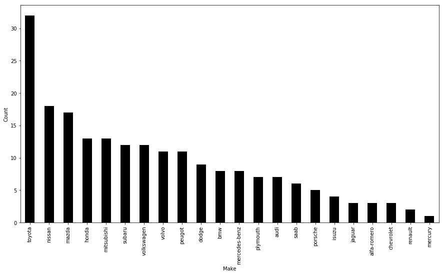

```python
automobile.make.value_counts().plot(figsize=(15,8),kind='bar',stacked=True,colormap='bone')
plt.xlabel('Make')
plt.ylabel('Count')
```

### Univariate Analysis on 'no-of-cylinders'

```
Text(0,0.5,'Count')
```

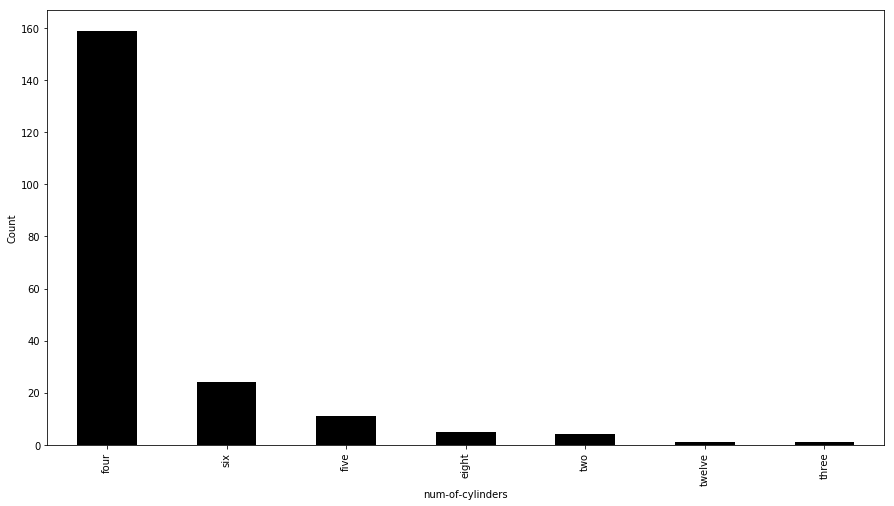

```python
automobile['num-of-cylinders'].value_counts().plot(figsize=(15,8),kind='bar',stacked=True,colormap='bone')
plt.xlabel('num-of-cylinders')
plt.ylabel('Count')
```

### Univariate Analysis on 'Fuel System'

```
Text(0,0.5,'fuel-system')
```

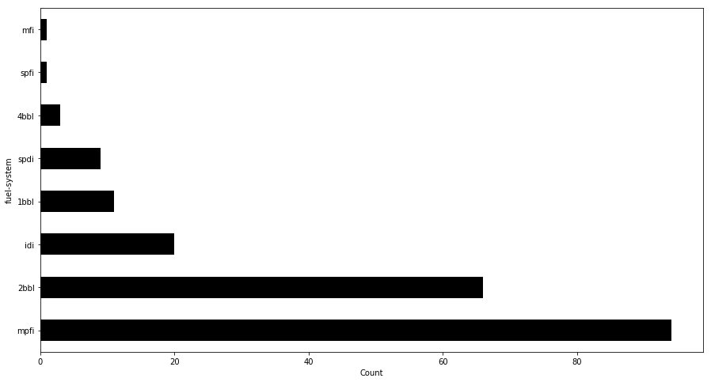

```python
automobile['fuel-system'].value_counts().plot(figsize=(15,8),kind='barh',stacked=True,colormap='bone')
plt.xlabel('Count')
plt.ylabel('fuel-system')
```

### Univaraite Analysis on 'Drive Wheels'

```
Text(0,0.5,'Count')
```

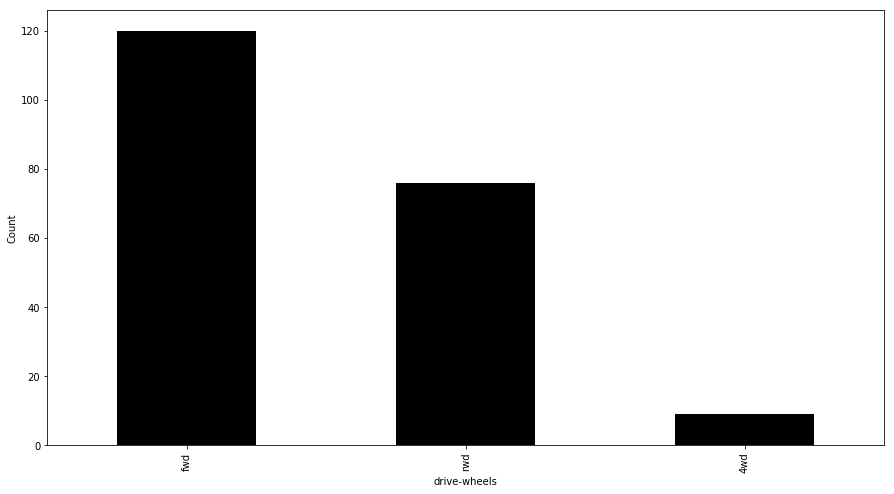

```python
automobile['drive-wheels'].value_counts().plot(figsize=(15,8),kind='bar',stacked=True,colormap='bone')
plt.xlabel('drive-wheels')
plt.ylabel('Count')
```

#### Plotting 'Histogram' and also calculating the mean from the data pertaining to 'Price of Cars'.

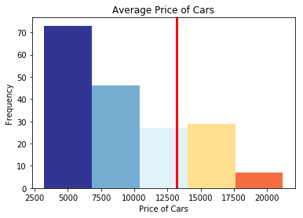

```python
import numpy as n
import matplotlib.pyplot as plt


# This is  the colormap I'd like to use.
cm = plt.cm.get_cmap('RdYlBu_r')

# Get the histogramp
Y,X = n.histogram(automobile['price'], range=(5000,23000),bins=5)
plt.xlabel("Price of Cars")
plt.ylabel("Frequency")
plt.title("Average Price of Cars")
plt.axvline(x=automobile['price'].mean(),linewidth=3,color='r')
x_span = X.max()-X.min()
C = [cm(((x-X.min())/x_span)) for x in X]

plt.bar(X[:-1],Y,color=C,width=X[1]-X[0])
plt.show()
```

### The Average 'MPG in City' is calculated using the Histogram

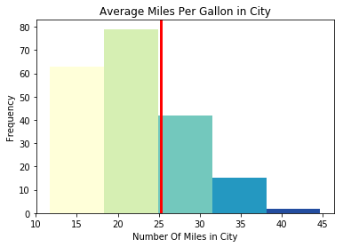

```python
import numpy as n
import matplotlib.pyplot as plt

# This is  the colormap I'd like to use.
cm = plt.cm.get_cmap('YlGnBu')

# Get the histogramp
Y,X = n.histogram(automobile['city-mpg'], range=(15,48),bins=5)
plt.xlabel("Number Of Miles in City")
plt.ylabel("Frequency")
plt.title("Average Miles Per Gallon in City")
plt.axvline(x=automobile['city-mpg'].mean(),linewidth=3,color='r')
x_span = X.max()-X.min()
C = [cm(((x-X.min())/x_span)) for x in X]

plt.bar(X[:-1],Y,color=C,width=X[1]-X[0])
plt.show()
```

### The Average 'MPG on Highway' is calculated using the Histogram

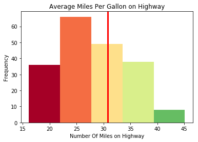

```python
import numpy as n
import matplotlib.pyplot as plt

# This is  the colormap I'd like to use.
cm = plt.cm.get_cmap('RdYlGn')

# Get the histogramp
Y,X = n.histogram(automobile['highway-mpg'], range=(19,48),bins=5)
plt.xlabel("Number Of Miles on Highway")
plt.ylabel("Frequency")
plt.title("Average Miles Per Gallon on Highway")
plt.axvline(x=automobile['highway-mpg'].mean(),linewidth=3,color='r')
x_span = X.max()-X.min()
C = [cm(((x-X.min())/x_span)) for x in X]

plt.bar(X[:-1],Y,color=C,width=X[1]-X[0])
plt.show()
```

# Performance Criteria

### *A few variables add up to the Performance of a car and also, how it compares with the actual meaning of how the performance variables are taken.Below are few which are taken into Performance Criteria Variables/factors.

#### 1. Bore Vs Stroke Ratio

#### 2. Bore/Stroke Ratio Vs Horsepower

#### 3. Oversquared Vs Undersquared Engines

#### 4. RPM Vs Torque

## 1. In the below dataset we are creating a new column named 'bore_stroke_ratio' for the ratio between Bore and Stroke.

```python
automobile['bore_stroke_ratio'] = automobile['bore']/automobile['stroke']
automobile
```

|  | symboling | normalized-losses | make | fuel-type | aspiration | num-of-doors | body-style | drive-wheels | engine-location | wheel-base | ... | fuel-system | bore | stroke | compression-ratio | horsepower | peak-rpm | city-mpg | highway-mpg | price | bore_stroke_ratio |
| --- | --- | --- | --- | --- | --- | --- | --- | --- | --- | --- | --- | --- | --- | --- | --- | --- | --- | --- | --- | --- | --- |
| 0 | 3 | NaN | alfa-romero | gas | std | two | convertible | rwd | front | 88.6 | ... | mpfi | 3.47 | 2.68 | 9.00 | 111.0 | 5000.0 | 21 | 27 | 13495.0 | 1.294776 |
| 1 | 3 | NaN | alfa-romero | gas | std | two | convertible | rwd | front | 88.6 | ... | mpfi | 3.47 | 2.68 | 9.00 | 111.0 | 5000.0 | 21 | 27 | 16500.0 | 1.294776 |
| 2 | 1 | NaN | alfa-romero | gas | std | two | hatchback | rwd | front | 94.5 | ... | mpfi | 2.68 | 3.47 | 9.00 | 154.0 | 5000.0 | 19 | 26 | 16500.0 | 0.772334 |
| 3 | 2 | 164 | audi | gas | std | four | sedan | fwd | front | 99.8 | ... | mpfi | 3.19 | 3.40 | 10.00 | 102.0 | 5500.0 | 24 | 30 | 13950.0 | 0.938235 |
| 4 | 2 | 164 | audi | gas | std | four | sedan | 4wd | front | 99.4 | ... | mpfi | 3.19 | 3.40 | 8.00 | 115.0 | 5500.0 | 18 | 22 | 17450.0 | 0.938235 |
| 5 | 2 | NaN | audi | gas | std | two | sedan | fwd | front | 99.8 | ... | mpfi | 3.19 | 3.40 | 8.50 | 110.0 | 5500.0 | 19 | 25 | 15250.0 | 0.938235 |
| 6 | 1 | 158 | audi | gas | std | four | sedan | fwd | front | 105.8 | ... | mpfi | 3.19 | 3.40 | 8.50 | 110.0 | 5500.0 | 19 | 25 | 17710.0 | 0.938235 |
| 7 | 1 | NaN | audi | gas | std | four | wagon | fwd | front | 105.8 | ... | mpfi | 3.19 | 3.40 | 8.50 | 110.0 | 5500.0 | 19 | 25 | 18920.0 | 0.938235 |
| 8 | 1 | 158 | audi | gas | turbo | four | sedan | fwd | front | 105.8 | ... | mpfi | 3.13 | 3.40 | 8.30 | 140.0 | 5500.0 | 17 | 20 | 23875.0 | 0.920588 |
| 9 | 0 | NaN | audi | gas | turbo | two | hatchback | 4wd | front | 99.5 | ... | mpfi | 3.13 | 3.40 | 7.00 | 160.0 | 5500.0 | 16 | 22 | NaN | 0.920588 |
| 10 | 2 | 192 | bmw | gas | std | two | sedan | rwd | front | 101.2 | ... | mpfi | 3.50 | 2.80 | 8.80 | 101.0 | 5800.0 | 23 | 29 | 16430.0 | 1.250000 |
| 11 | 0 | 192 | bmw | gas | std | four | sedan | rwd | front | 101.2 | ... | mpfi | 3.50 | 2.80 | 8.80 | 101.0 | 5800.0 | 23 | 29 | 16925.0 | 1.250000 |
| 12 | 0 | 188 | bmw | gas | std | two | sedan | rwd | front | 101.2 | ... | mpfi | 3.31 | 3.19 | 9.00 | 121.0 | 4250.0 | 21 | 28 | 20970.0 | 1.037618 |
| 13 | 0 | 188 | bmw | gas | std | four | sedan | rwd | front | 101.2 | ... | mpfi | 3.31 | 3.19 | 9.00 | 121.0 | 4250.0 | 21 | 28 | 21105.0 | 1.037618 |
| 14 | 1 | NaN | bmw | gas | std | four | sedan | rwd | front | 103.5 | ... | mpfi | 3.31 | 3.19 | 9.00 | 121.0 | 4250.0 | 20 | 25 | 24565.0 | 1.037618 |
| 15 | 0 | NaN | bmw | gas | std | four | sedan | rwd | front | 103.5 | ... | mpfi | 3.62 | 3.39 | 8.00 | 182.0 | 5400.0 | 16 | 22 | 30760.0 | 1.067847 |
| 16 | 0 | NaN | bmw | gas | std | two | sedan | rwd | front | 103.5 | ... | mpfi | 3.62 | 3.39 | 8.00 | 182.0 | 5400.0 | 16 | 22 | 41315.0 | 1.067847 |
| 17 | 0 | NaN | bmw | gas | std | four | sedan | rwd | front | 110.0 | ... | mpfi | 3.62 | 3.39 | 8.00 | 182.0 | 5400.0 | 15 | 20 | 36880.0 | 1.067847 |
| 18 | 2 | 121 | chevrolet | gas | std | two | hatchback | fwd | front | 88.4 | ... | 2bbl | 2.91 | 3.03 | 9.50 | 48.0 | 5100.0 | 47 | 53 | 5151.0 | 0.960396 |
| 19 | 1 | 98 | chevrolet | gas | std | two | hatchback | fwd | front | 94.5 | ... | 2bbl | 3.03 | 3.11 | 9.60 | 70.0 | 5400.0 | 38 | 43 | 6295.0 | 0.974277 |
| 20 | 0 | 81 | chevrolet | gas | std | four | sedan | fwd | front | 94.5 | ... | 2bbl | 3.03 | 3.11 | 9.60 | 70.0 | 5400.0 | 38 | 43 | 6575.0 | 0.974277 |
| 21 | 1 | 118 | dodge | gas | std | two | hatchback | fwd | front | 93.7 | ... | 2bbl | 2.97 | 3.23 | 9.41 | 68.0 | 5500.0 | 37 | 41 | 5572.0 | 0.919505 |
| 22 | 1 | 118 | dodge | gas | std | two | hatchback | fwd | front | 93.7 | ... | 2bbl | 2.97 | 3.23 | 9.40 | 68.0 | 5500.0 | 31 | 38 | 6377.0 | 0.919505 |
| 23 | 1 | 118 | dodge | gas | turbo | two | hatchback | fwd | front | 93.7 | ... | mpfi | 3.03 | 3.39 | 7.60 | 102.0 | 5500.0 | 24 | 30 | 7957.0 | 0.893805 |
| 24 | 1 | 148 | dodge | gas | std | four | hatchback | fwd | front | 93.7 | ... | 2bbl | 2.97 | 3.23 | 9.40 | 68.0 | 5500.0 | 31 | 38 | 6229.0 | 0.919505 |
| 25 | 1 | 148 | dodge | gas | std | four | sedan | fwd | front | 93.7 | ... | 2bbl | 2.97 | 3.23 | 9.40 | 68.0 | 5500.0 | 31 | 38 | 6692.0 | 0.919505 |
| 26 | 1 | 148 | dodge | gas | std | four | sedan | fwd | front | 93.7 | ... | 2bbl | 2.97 | 3.23 | 9.40 | 68.0 | 5500.0 | 31 | 38 | 7609.0 | 0.919505 |
| 27 | 1 | 148 | dodge | gas | turbo | NaN | sedan | fwd | front | 93.7 | ... | mpfi | 3.03 | 3.39 | 7.60 | 102.0 | 5500.0 | 24 | 30 | 8558.0 | 0.893805 |
| 28 | -1 | 110 | dodge | gas | std | four | wagon | fwd | front | 103.3 | ... | 2bbl | 3.34 | 3.46 | 8.50 | 88.0 | 5000.0 | 24 | 30 | 8921.0 | 0.965318 |
| 29 | 3 | 145 | dodge | gas | turbo | two | hatchback | fwd | front | 95.9 | ... | mfi | 3.60 | 3.90 | 7.00 | 145.0 | 5000.0 | 19 | 24 | 12964.0 | 0.923077 |
| ... | ... | ... | ... | ... | ... | ... | ... | ... | ... | ... | ... | ... | ... | ... | ... | ... | ... | ... | ... | ... | ... |
| 175 | -1 | 65 | toyota | gas | std | four | hatchback | fwd | front | 102.4 | ... | mpfi | 3.31 | 3.54 | 8.70 | 92.0 | 4200.0 | 27 | 32 | 9988.0 | 0.935028 |
| 176 | -1 | 65 | toyota | gas | std | four | sedan | fwd | front | 102.4 | ... | mpfi | 3.31 | 3.54 | 8.70 | 92.0 | 4200.0 | 27 | 32 | 10898.0 | 0.935028 |
| 177 | -1 | 65 | toyota | gas | std | four | hatchback | fwd | front | 102.4 | ... | mpfi | 3.31 | 3.54 | 8.70 | 92.0 | 4200.0 | 27 | 32 | 11248.0 | 0.935028 |
| 178 | 3 | 197 | toyota | gas | std | two | hatchback | rwd | front | 102.9 | ... | mpfi | 3.27 | 3.35 | 9.30 | 161.0 | 5200.0 | 20 | 24 | 16558.0 | 0.976119 |
| 179 | 3 | 197 | toyota | gas | std | two | hatchback | rwd | front | 102.9 | ... | mpfi | 3.27 | 3.35 | 9.30 | 161.0 | 5200.0 | 19 | 24 | 15998.0 | 0.976119 |
| 180 | -1 | 90 | toyota | gas | std | four | sedan | rwd | front | 104.5 | ... | mpfi | 3.27 | 3.35 | 9.20 | 156.0 | 5200.0 | 20 | 24 | 15690.0 | 0.976119 |
| 181 | -1 | NaN | toyota | gas | std | four | wagon | rwd | front | 104.5 | ... | mpfi | 3.27 | 3.35 | 9.20 | 156.0 | 5200.0 | 19 | 24 | 15750.0 | 0.976119 |
| 182 | 2 | 122 | volkswagen | diesel | std | two | sedan | fwd | front | 97.3 | ... | idi | 3.01 | 3.40 | 23.00 | 52.0 | 4800.0 | 37 | 46 | 7775.0 | 0.885294 |
| 183 | 2 | 122 | volkswagen | gas | std | two | sedan | fwd | front | 97.3 | ... | mpfi | 3.19 | 3.40 | 9.00 | 85.0 | 5250.0 | 27 | 34 | 7975.0 | 0.938235 |
| 184 | 2 | 94 | volkswagen | diesel | std | four | sedan | fwd | front | 97.3 | ... | idi | 3.01 | 3.40 | 23.00 | 52.0 | 4800.0 | 37 | 46 | 7995.0 | 0.885294 |
| 185 | 2 | 94 | volkswagen | gas | std | four | sedan | fwd | front | 97.3 | ... | mpfi | 3.19 | 3.40 | 9.00 | 85.0 | 5250.0 | 27 | 34 | 8195.0 | 0.938235 |
| 186 | 2 | 94 | volkswagen | gas | std | four | sedan | fwd | front | 97.3 | ... | mpfi | 3.19 | 3.40 | 9.00 | 85.0 | 5250.0 | 27 | 34 | 8495.0 | 0.938235 |
| 187 | 2 | 94 | volkswagen | diesel | turbo | four | sedan | fwd | front | 97.3 | ... | idi | 3.01 | 3.40 | 23.00 | 68.0 | 4500.0 | 37 | 42 | 9495.0 | 0.885294 |
| 188 | 2 | 94 | volkswagen | gas | std | four | sedan | fwd | front | 97.3 | ... | mpfi | 3.19 | 3.40 | 10.00 | 100.0 | 5500.0 | 26 | 32 | 9995.0 | 0.938235 |
| 189 | 3 | NaN | volkswagen | gas | std | two | convertible | fwd | front | 94.5 | ... | mpfi | 3.19 | 3.40 | 8.50 | 90.0 | 5500.0 | 24 | 29 | 11595.0 | 0.938235 |
| 190 | 3 | 256 | volkswagen | gas | std | two | hatchback | fwd | front | 94.5 | ... | mpfi | 3.19 | 3.40 | 8.50 | 90.0 | 5500.0 | 24 | 29 | 9980.0 | 0.938235 |
| 191 | 0 | NaN | volkswagen | gas | std | four | sedan | fwd | front | 100.4 | ... | mpfi | 3.19 | 3.40 | 8.50 | 110.0 | 5500.0 | 19 | 24 | 13295.0 | 0.938235 |
| 192 | 0 | NaN | volkswagen | diesel | turbo | four | sedan | fwd | front | 100.4 | ... | idi | 3.01 | 3.40 | 23.00 | 68.0 | 4500.0 | 33 | 38 | 13845.0 | 0.885294 |
| 193 | 0 | NaN | volkswagen | gas | std | four | wagon | fwd | front | 100.4 | ... | mpfi | 3.19 | 3.40 | 9.00 | 88.0 | 5500.0 | 25 | 31 | 12290.0 | 0.938235 |
| 194 | -2 | 103 | volvo | gas | std | four | sedan | rwd | front | 104.3 | ... | mpfi | 3.78 | 3.15 | 9.50 | 114.0 | 5400.0 | 23 | 28 | 12940.0 | 1.200000 |
| 195 | -1 | 74 | volvo | gas | std | four | wagon | rwd | front | 104.3 | ... | mpfi | 3.78 | 3.15 | 9.50 | 114.0 | 5400.0 | 23 | 28 | 13415.0 | 1.200000 |
| 196 | -2 | 103 | volvo | gas | std | four | sedan | rwd | front | 104.3 | ... | mpfi | 3.78 | 3.15 | 9.50 | 114.0 | 5400.0 | 24 | 28 | 15985.0 | 1.200000 |
| 197 | -1 | 74 | volvo | gas | std | four | wagon | rwd | front | 104.3 | ... | mpfi | 3.78 | 3.15 | 9.50 | 114.0 | 5400.0 | 24 | 28 | 16515.0 | 1.200000 |
| 198 | -2 | 103 | volvo | gas | turbo | four | sedan | rwd | front | 104.3 | ... | mpfi | 3.62 | 3.15 | 7.50 | 162.0 | 5100.0 | 17 | 22 | 18420.0 | 1.149206 |
| 199 | -1 | 74 | volvo | gas | turbo | four | wagon | rwd | front | 104.3 | ... | mpfi | 3.62 | 3.15 | 7.50 | 162.0 | 5100.0 | 17 | 22 | 18950.0 | 1.149206 |
| 200 | -1 | 95 | volvo | gas | std | four | sedan | rwd | front | 109.1 | ... | mpfi | 3.78 | 3.15 | 9.50 | 114.0 | 5400.0 | 23 | 28 | 16845.0 | 1.200000 |
| 201 | -1 | 95 | volvo | gas | turbo | four | sedan | rwd | front | 109.1 | ... | mpfi | 3.78 | 3.15 | 8.70 | 160.0 | 5300.0 | 19 | 25 | 19045.0 | 1.200000 |
| 202 | -1 | 95 | volvo | gas | std | four | sedan | rwd | front | 109.1 | ... | mpfi | 3.58 | 2.87 | 8.80 | 134.0 | 5500.0 | 18 | 23 | 21485.0 | 1.247387 |
| 203 | -1 | 95 | volvo | diesel | turbo | four | sedan | rwd | front | 109.1 | ... | idi | 3.01 | 3.40 | 23.00 | 106.0 | 4800.0 | 26 | 27 | 22470.0 | 0.885294 |
| 204 | -1 | 95 | volvo | gas | turbo | four | sedan | rwd | front | 109.1 | ... | mpfi | 3.78 | 3.15 | 9.50 | 114.0 | 5400.0 | 19 | 25 | 22625.0 | 1.200000 |

205 rows × 27 columns

# Note - The Bore/Stroke gives us how much Power/Torque a car has.

## - If the Ratio is more than 1 it is said to be having more 'RPM'(Powerful).

## - If the Ratio is less than 1 it is said to be having more Torque.

# 2. But not Bore/Stroke alone can be taken to judge a car's performance. It should also match with BHP(Break Horse Power) and Vice-Versa.

### Below is where we plot a graph between Bore/Stroke Ratio Vs Horsepower to see at what interval the cars in the dataset has an equally good Bore/Stroke and higher BHP.

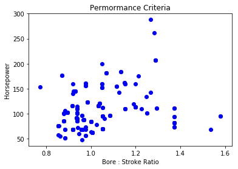

```python
import numpy as np
import matplotlib.pyplot as plt

plt.scatter(automobile['bore_stroke_ratio'],automobile['horsepower'],color='blue')
plt.title('Permormance Criteria')
plt.xlabel('Bore : Stroke Ratio')
plt.ylabel('Horsepower')
plt.show()
```

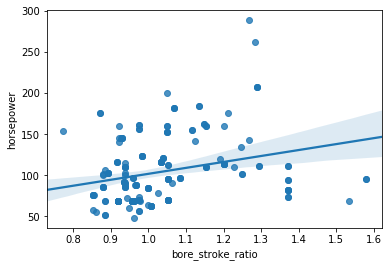

```python
sns.regplot(x='bore_stroke_ratio', y='horsepower', data=automobile)
```

# 3. The concept of 'Oversquared' and 'Undersquared' Engines are nothing but the engines which have greater than 1 Ratio is called 'Oversquared' and engines which have less than 1 Ratio is called 'Undersquared'.

### Below is where we see the number of 'Oversquared' and 'Undersquared' engines we have from the provided dataset and the average of it.

#### * Below is where we plot and see how many Oversquared Engines are present and the average of it.

```python
oversquared = automobile[automobile['bore_stroke_ratio']>1]
```

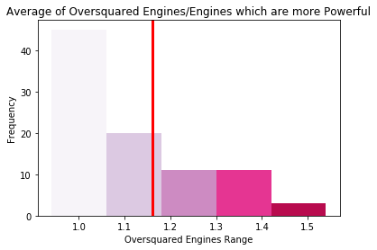

```python
import numpy as n
import matplotlib.pyplot as plt

# This is  the colormap I'd like to use.
cm = plt.cm.get_cmap('PuRd')

# Get the histogramp
Y,X = n.histogram(oversquared['bore_stroke_ratio'], range=(1,1.6),bins=5)
plt.xlabel("Oversquared Engines Range")
plt.ylabel("Frequency")
plt.title("Average of Oversquared Engines/Engines which are more Powerful")
plt.axvline(x=oversquared['bore_stroke_ratio'].mean(),linewidth=3,color='r')
x_span = X.max()-X.min()
C = [cm(((x-X.min())/x_span)) for x in X]

plt.bar(X[:-1],Y,color=C,width=X[1]-X[0])
plt.show()
```

#### The number of 'Oversquared' Engines are 90.

```python
oversquared.shape
```

```
(90, 27)
```

#### * Below is where we plot and see how many Underaquared Engines are present and the average of it.

```python
undersquared = automobile[automobile['bore_stroke_ratio']<1]
```

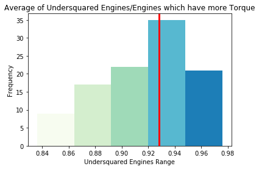

```python
import numpy as n
import matplotlib.pyplot as plt

# This is  the colormap I'd like to use.
cm = plt.cm.get_cmap('GnBu')

# Get the histogramp
Y,X = n.histogram(undersquared['bore_stroke_ratio'], range=(0.85,0.99),bins=5)
plt.xlabel("Undersquared Engines Range")
plt.ylabel("Frequency")
plt.title("Average of Undersquared Engines/Engines which have more Torque")
plt.axvline(x=undersquared['bore_stroke_ratio'].mean(),linewidth=3,color='r')
x_span = X.max()-X.min()
C = [cm(((x-X.min())/x_span)) for x in X]

plt.bar(X[:-1],Y,color=C,width=X[1]-X[0])
plt.show()
```

#### The number of 'Undersquared' Engines are 105.

```python
undersquared.shape
```

```
(105, 27)
```

```python
automobile['oversquared']=automobile['bore_stroke_ratio']>1
```

```python
automobile['undersquared']=automobile['bore_stroke_ratio']<1
```